[▶ Run this notebook in VEClim Tutorials](https://veclim.com/tutorials/hub/spawn?file_path=tutorials/Nicosia2025/DDE/DDE_tutorial.ipynb)

# Introduction to modelling vector dynamics with DDEs

Dom Brass (UKCEH) - dombra@ceh.ac.uk

## Introduction to DDEs

Delay-Differential Equations (DDEs) allow the dynamics of a system to depend on the state of the system at past times. This is often a useful feature as it allows us to track development times and ensure that biological processes finish at realistic times. This makes them a good option for models when timing is something we want to predict precisely (for example, vector-borne disease transmission cycles). Our group uses DDE approaches to predict the dynamics of a range of mosquito and tick vectors (see for example https://www.nature.com/articles/s41467-024-52144-5). In this tutorial I will demonstrate how to implement temperature driven DDE models of population dynamics in R and highlight some common pitfalls to avoid.

### A simple model

Consider a simple 2-stage ODE model where individual's transfer at from stage $y_1$ to stage $y_2$ at a rate of $r$ individuals per day,

$$\begin{align}\frac{dy_1}{dt} &= -ry_1(t)\\ \frac{dy_2}{dt} &= ry_1(t) \end{align}$$

and a DDE where instead it takes $\tau = 1/r$ days for an individual to finish development and move from stage $y_1$ to stage $y_2$,

$$\begin{align}\frac{dy_1}{dt} &= -y_1(t - \tau)\\ \frac{dy_2}{dt} &= y_1(t - \tau). \end{align}$$

We will simulate the dynamics of these systems with initial conditions $y_1(0)=10,000, y_2(0) = 0$ and with history $y_1(t)=10,000, y_2(t) = 0$ for $t<0$.

[output not shown]

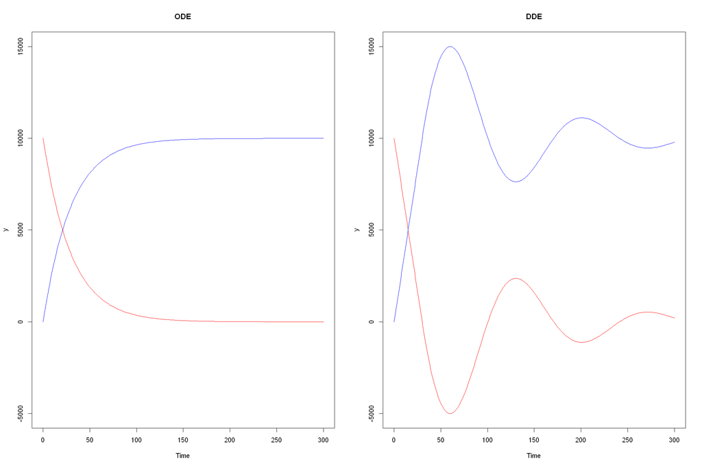

The solution to the previous DDE goes negative and predicts a population that is too large because we did not carefully define the systems history. Intuitively this occurs because the delay looks backwards to the past and "sees" $\tau$ days of $y_1 = 10,000$, which then get fed through to $y_2$ despite our initial intention to only have $10,000$ individuals. This results in the strange oscillatory dynamics as the system compensates. To fix this we could either be more careful with how we define the systems history or much lazier with how we define the initial conditions. Because we eventually will have a very complex system with many stages, states, and life-history processes we opt to be lazy and set initial conditions $y_1(0)=0, y_2(0) = 0$ and with history $y_1(t)=0, y_2(t) = 0$ for $t<0$. To initiate the dynamics we instead define an impulse function, $I(t)$, that is $0$ everywhere apart for when $t\in[0,10]$ for which we will have $I(t) = 1,000$ to introduce the $10,000$ individuals we intended to start with at a rate of $1,000$ individuals per day. The new ODE system is defined

$$\begin{align}\frac{dy_1}{dt} &= I(t) -ry_1(t) \\ \frac{dy_2}{dt} &= ry_1(t) \end{align}$$

and the new DDE is defined

$$\begin{align}\frac{dy_1}{dt} &= I(t)-I(t - \tau)\\ \frac{dy_2}{dt} &= I(t - \tau). \end{align}$$

Once you've run the model with the supplied parameters, try changing both the impulse function and the delay to get a feel for how the two models compare.

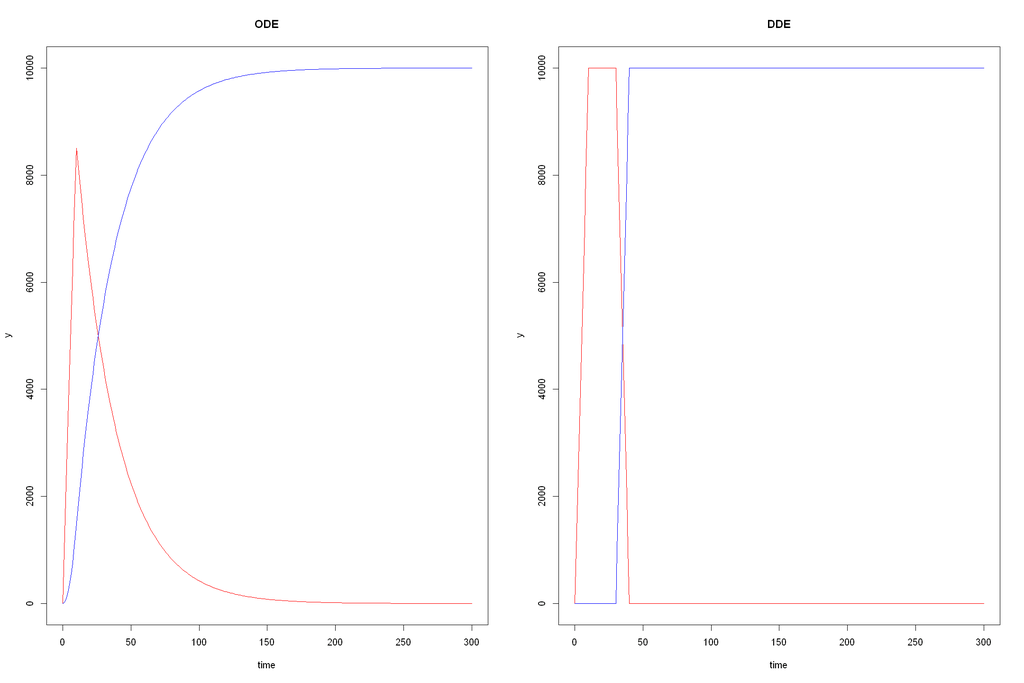

The effect of accounting for the movement of individuals from one stage to the next in different ways can be seen more clearly when we consider more stages. See for example this $5$-stage model that follows the same basic pattern as the previous, notice the effect that assuming a constant transfer of individuals to the next stage at a constant rate has on when we first observe individuals.

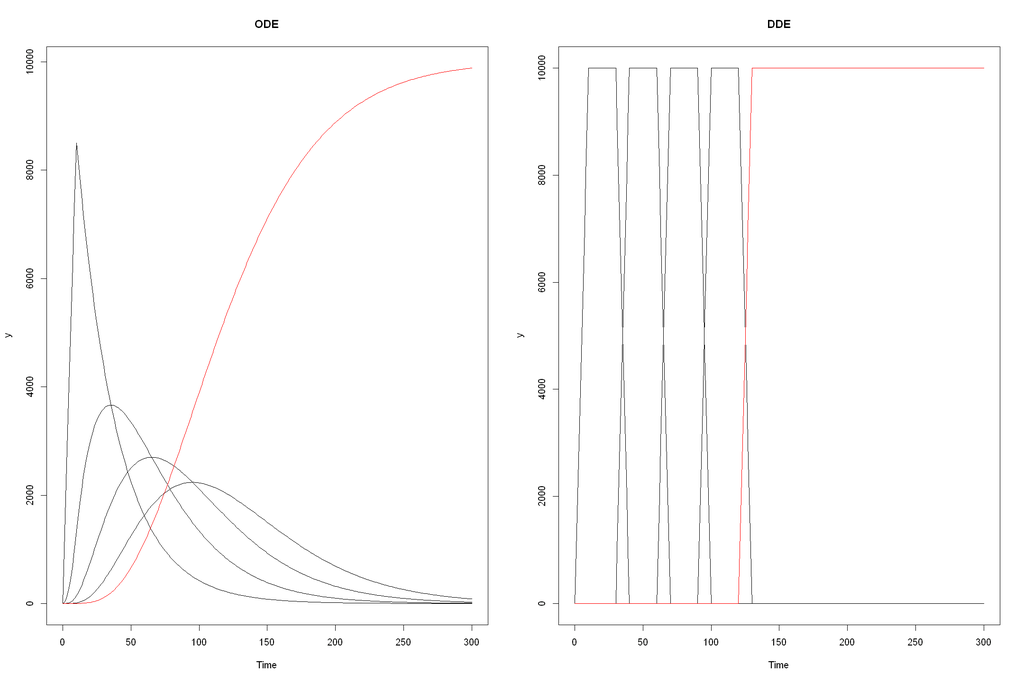

## Density dependence

So far, we have seen the effect that delays can have on the timing of events within a system. This is intuitive, but delays can also have less obvious effects on population dynamics especially in instances where there is delayed-density dependence in the system. Consider the dynamical behaviour of the following ODE describing logistic growth where the population increases with rate $r$ and has carrying capacity $K$:

$$\frac{dy}{dt} = ry\left(1-\frac{y(t)}{K}\right)$$

and a DDE describing delay logistic growth

$$\frac{dy}{dt} = ry\left(1-\frac{y(t - \tau)}{K}\right)$$

We implement the models:

Try simulating the system for different values of $\tau$, what do you observe as the delay increases?

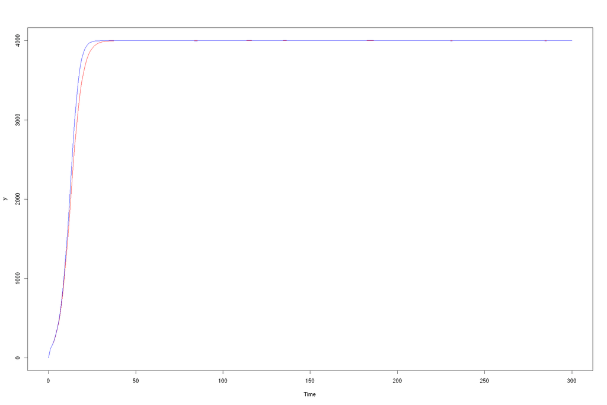

So we might want to think about using a DDE when we care about timing or when we are interested in the effects of density dependence.

## The Nisbet and Gurney approach

The previous examples show that the dynamics of DDEs are often more complicated than we observe in similarly formulated ODEs. However, we need to also show that this extra complexity is justified and actually improve our understanding of population dynamics. To do this we introduce a standard framework within which to formulate DDEs and examine our first serious DDE model of population dynamics.

We will consider the dynamics of a laboratory system of caged blowflies that Nicholson kept in 1950 (described in "The Self-Adjustment of Populations to Change" - A. J. NICHOLSON). The blowflies were kept at a constant temperature and provided with a fixed amount of food every day, with larval and adult food supplies separated. Larval food was assumed to be in excess (we will return to this assumption later) and adult food was supplied at a level that it was the factor limiting the size of the population. The Nicholson observed that the effect of competition for adult food on adult traits was a reduction in the number of eggs laid, which he measured through a series of experiments. The dynamics expressed by the fly population were characterised by oscillatory cycles, with periods of high adult abundance but low numbers of eggs and low adult abundance but high numbers of eggs.

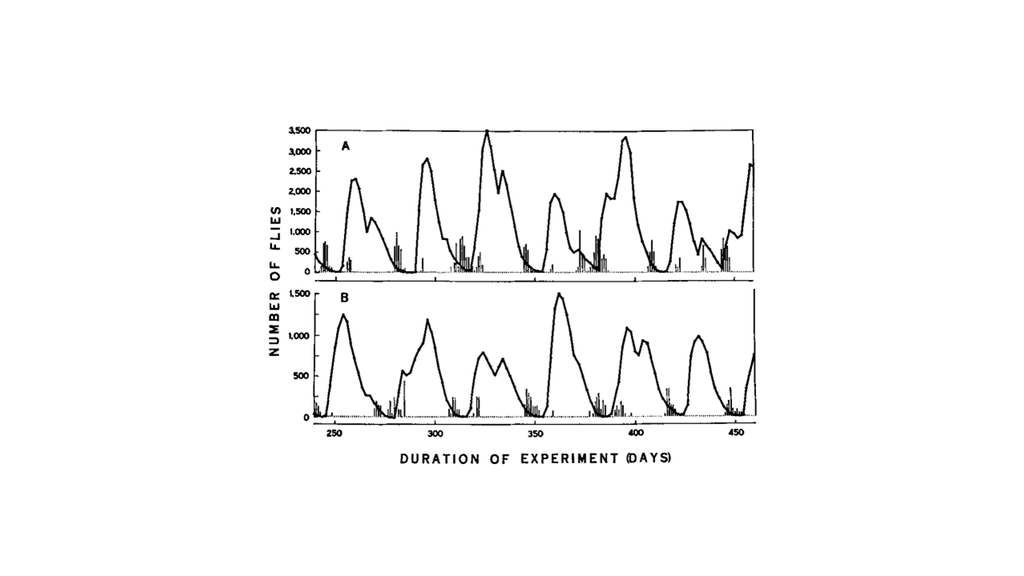

In "Nicholson's blowflies revisited" W. S. C. Gurney, S. P. Blythe & R. M. Nisbet propose a system of DDEs to model this population which we will now simulate which then became the basis of a framework we can use to create stage-structured systems of DDEs without worrying too much about the analytics.

We define the rates of change in the state variables in terms of recruitment into a stage $R_X(t)$, maturation out of a stage $M_X(t)$. For each stage we additionally define a duration $\tau_X$, and a mortality rate, $\delta_X$, which we additionally use to define a through-stage survival proportion $P_X = \exp(-\delta_X\tau_X)$.

Recruitment into the egg stage, E(t), is defined $$R_E(t) = 8.5A(t)\exp(-A(t)/600) + I(t)$$ representing the effect of food limitation on egg production. Maturation out of the egg stage and into the larval stage is the defined $$\begin{align}M_E(t) &= R_L(t)\\ &= R_E(t - \tau_E)P_E\\ &= (8.5A(t-\tau_E)\exp(-A(t-\tau_E)/600 + I(t-\tau_E))P_E\end{align},$$ which states that the rate at which individuals leave the egg stage at time $t$ is equal to the rate they entered the egg stage one development period ago modified by the proportion of individuals that survived development. We then can similarly recursively define the rest of the recruitment and maturation rates using a similar logic, i.e. $$\begin{align}M_{i}(t) &= R_{i+1}(t)\\ &= R_{i}(t - \tau_L)P_i\end{align}$$ and so on. This results in the following system of equations: $$ \begin{align} \frac{dE}{dt} &= R_E(t) - M_E(t) - \delta_EE(t),\\ \frac{dL}{dt} &= R_L(t) - M_L(t) - \delta_LL(t),\\ \frac{dP}{dt} &= R_P(t) - M_P(t) - \delta_PP(t),\\ \frac{dJ}{dt} &= R_J(t) - M_J(t) - \delta_JJ(t),\\ \frac{dA}{dt} &= R_A(t) - \delta_AA(t). \end{align} $$

We compare the dynamics of this system to an equivalent system of ODEs where we represent development with rates rather than durations, i.e $g_E = 1/\tau_E$:

$$ \begin{align} \frac{dE}{dt} &= R_E(t) - g_EE(t) - \delta_EE(t),\\ \frac{dL}{dt} &= g_EE(t) - g_LL(t) - \delta_LL(t),\\ \frac{dP}{dt} &= g_LL(t) - g_PP(t) - \delta_PP(t),\\ \frac{dJ}{dt} &= g_PP(t) - g_JJ(t) - \delta_JJ(t),\\ \frac{dA}{dt} &= g_JJ(t) - \delta_AA(t). \end{align} $$

We define the model

In general we see that a very simple sort of density dependence naturally explains complex dynamics observed in a real population. Try changing the parameters what behaviours can you observe?

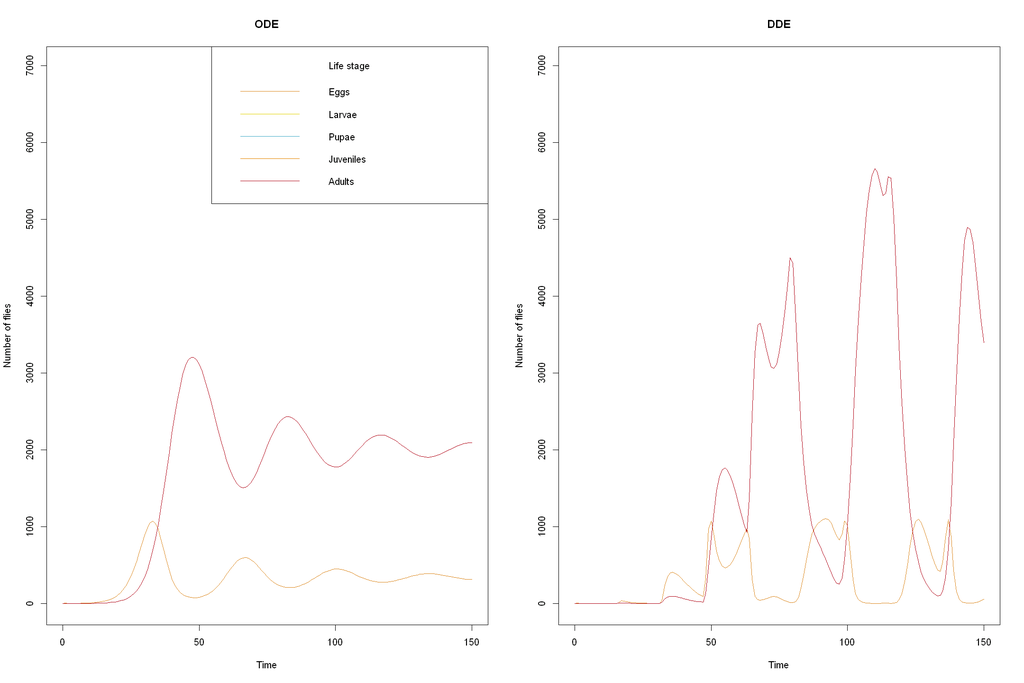

## Variable delays

So far we have considered only models with constant delays, but for climate sensitive vectors we are most often concerned with temperature dependent development rates. To account for variable delays in a DDE way requires extra accounting, for which we will follow the approach described in "The systematic formulation of population models for insects with dynamically varying instar duration" - R.M. Nisbet, W.S.C. Gurney. To explain this framework we will slowly build to a toy model for a "mosquitoes" population dynamics.

To describe the rate at which the stage duration varies we require an additional state-equation that will define the rate at which the total stage duration of individuals maturing at time $t$ changes and a corresponding state-equation for the effect this has on the through stage-survival proportion.

Try changing the sinusoidal temperature function, and the variable "mod" which scales the stage duration. What do you observe?

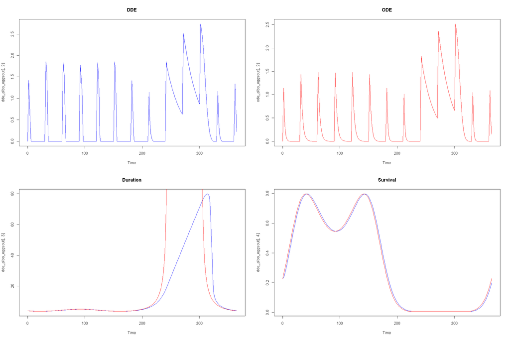

As before we now extend the model to include multiple stages (Eggs, Larvae, Pupae, Adults), all of which have different roughly mosquito-like stage durations and survivals. Note that to recall the state of the system at previous times we now have to embed delays within other delays. For example, if we wanted to know how many adults were in the system one generation ago the delay term is expressed $$A(t - \tau_P(t) - \tau_L(t - \tau_P(t)) - \tau_E(t - \tau_L(t - \tau_P(t)))$$ this sort of delay term can quickly become unwieldy so it's important to ensure your code is structured in a way that allows you to recall these past states accurately.

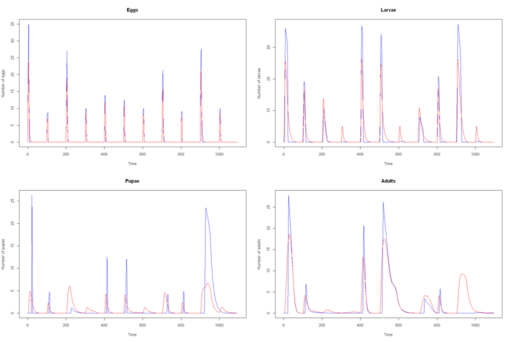

We now consider a full environmentally sensitive population model for vector dynamics and add back in a renewal process to represent egg laying. This requires us to also consider how the population density is regulated. Initially, we will achieve this by adding a crowding term to the larval mortality rate that will induce high levels of mortality when larval density exceeds an upper limit (don't worry about the dimensions!).

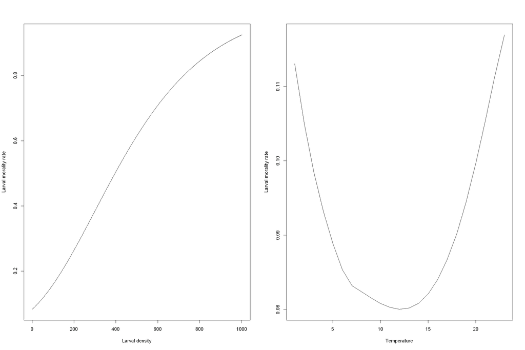

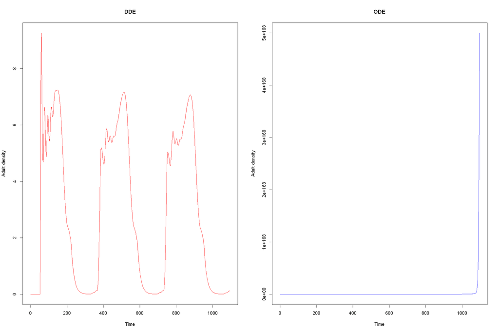

The previous example is somewhat silly as ODE models often account for density dependence through different processes such as predation. Uncomment the line of code the term $-L(t)^2/K$ to add "predation" into the ODE model and compare the dynamics, think about the experimental data you might need to parametrise each form of density dependence in a real model.

# Phenotypic plasticity (or carry-over effects) in DDEs

Mosquitoes are affected by larval density dependence instantaneously in the larval stage with increases in mortality and development rates. We can account for both of these using the formulations we have developed in the previous section. However, another effect of larval density dependence is on the traits that adult mosquitoes express, specifically adult survival and adult fecundity - both important in predicting population and disease dynamics. Thankfully the DDE framework can track the effects of previous density depedendent competition and assign them to cohorts of individuals in the adult stage. As prototypical example of this we return to the previous blowfly model.

Like mosquitoes, blowlfies also experience delayed consequences of larval competition. Blowflies specifically experience higher mortality through pupation and reduced maximum adult fecundity in addition to the effect that competition for adult food has on egg production. To represent this we modify the blowlfy model so that upon pupation we can assign adult blowflies to a cohort of individuals that all express the same trait as determined by that cohorts experience of larval competition, denoted $\alpha(t)$ (see schematic for model structure).

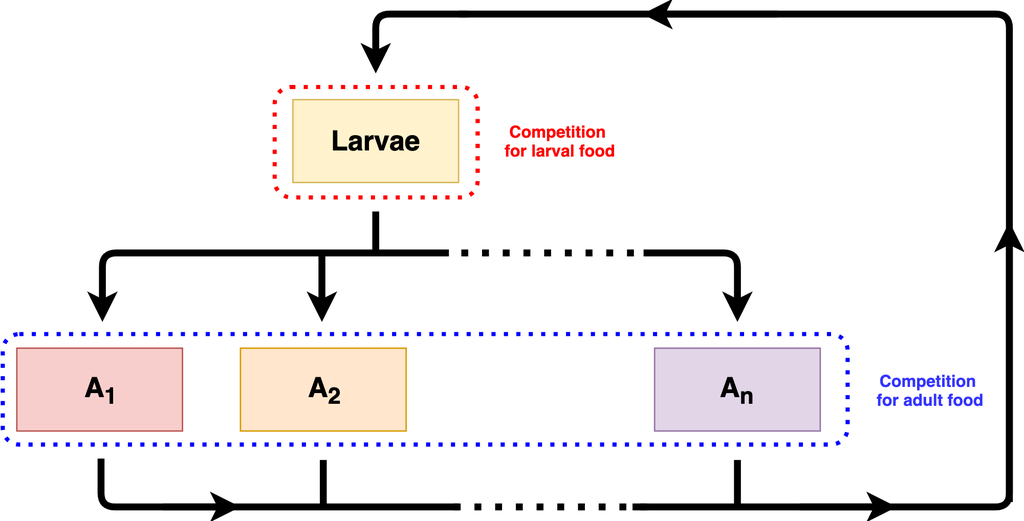

The model takes the form

$$\begin{align} \frac{dL(t)}{dt} &= R_L(t) - R_L(t-\tau_L)S_L - \delta_LL(t)\\ \frac{dA_j(t)}{dt} &= R_{A_j}(t) - \delta_{A} A_j(t)\,\,\,\, \textrm{for} \,\,\,j \in 1,...,m\\ \frac{d\alpha(t)}{dt} &= \frac{-\alpha^2(t)(L(t) - L(t-\tau_L))}{K_L\tau_L}. \end{align}$$

Recruitment terms are given by

$$\begin{align} R_L(t) &= \left[\sum^m_{j=1}q_jA_j(t-\tau_E)e^{-A_{\textrm{Tot}}(t-\tau_E)/K_A} + I(t-\tau_E)\right]S_E\\ R_{A_j}(t) &= \sum^m_{j=1}w_j(\alpha(t - \tau_P - \tau_J))R_L(t-\tau_L-\tau_P-\tau_J)S_LS_{J_j} \end{align}$$

$\textrm{for} \,\,\,j \in 1,...,m$ where $I(t-\tau_E)$ is an inoculation term that begins the dynamics, and represents the introduction of larvae into the system at $t=0$, and $q_j$ and $S_{J_j}$ are determined by the reaction norms we paramatrise below. These norms show that as larval competition increases we can expect a reduction in adult maximum fecundity and through pupal stage survival.

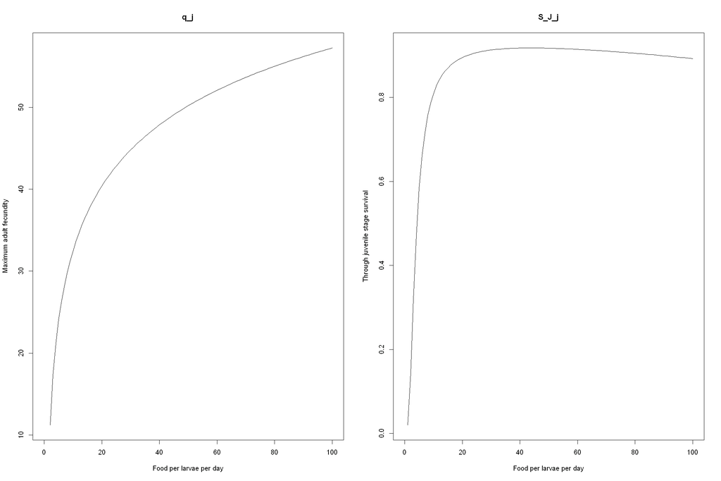

Nicholson ran a different cage experiment with same flies where after almost two years(!) supplying the adult population with unlimited food he reduced the food supply (results replicated in the graph below). What's strange about the behaviour we observe?

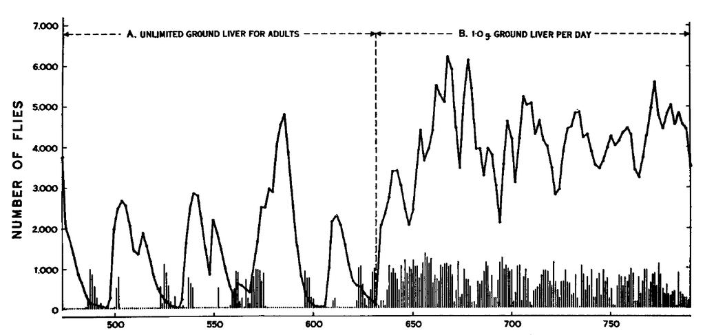

We set up the blowlfy model to replicate the switch in adult food supplies, try running the model (this will take longer than the previous models). Play around with the food before and after the switch to see what other dynamics emerge.

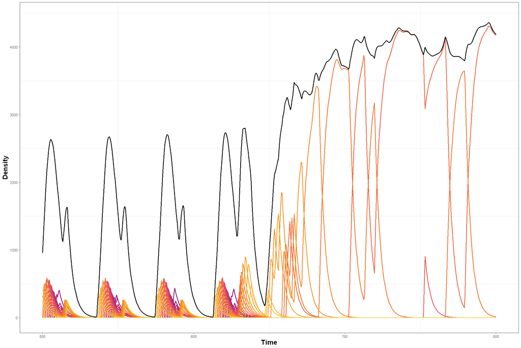

We can incorporate exactly the same mechanism, the idea of the effect of larval competition following through to alter adult trait directly into a mosquito model.

# Aedes albopictus and dengue

We finally come to a environmentally driven system of delay differential equations that describe the transmission of dengue by Aedes albopictus (as described fully in https://www.nature.com/articles/s41467-024-52144-5). We incorporate temperature dependent variable delays along side the persistant effects of larval competition on adult trait. There are many additional biological processes represented within the model, such as egg diapause, and resource dynamics, but all are constructed by combining the building blocks we've developed throughout the tutorial. A schematic representation of the model is shown below.

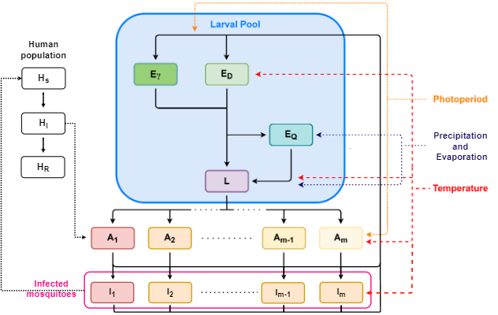

This model also contains both a human population and an infection structure the flow of individuals through the infection structure is mediated by delays - some temperature dependent (like the EIP) and some constant (like the IIP). In each of the following examples we introduce first a mosquito population and then, once the population has been established infected humans.

[figure not shown]

We then examine predictions of the number of human infections. Try changing how many and when infected people are introduced as well as the size of the human population.

[figure not shown]

Now try running the model under environmental conditions corresponding to Guangzhou in 2013/14.

[figure not shown]